# 04_Stroud_Hannah_2018

Hannah Stroud

October 1, 2018

## Hypothesis Testing

```r
library(dplyr)
```

```r
library(ggplot2)
library(tidyr)
```

### 1- W&S, Ch 6, Question 15,21, and 29

#### 1.1 Question 15

For the following alternative hypotheses, give the appropriate null hypothesis:

15a. The null hypothesis would be: There are no differences in mean femur length between pygmy mammoths and continental mammoths.

15b. Null: Patients who take phentermine and topiramate lose wait at the same rate as control patients that do not take these drugs.

15c. Null: Patients who take phentermine and topiramate have the same proportion of their babies born with cleft palates as patients who do not take these drugs.

15d. Null: On average shoppers do not buy different amounts of candy when Christmas music is playing in the shop compared to when the usual type of music is playing.

15e. Null: Male white-collared manakins dance as frequently when females are present as they do when females are absent.

#### 1.2 Question 21

Two researchers testing the same null hypothesis, all equal example n1=60 and n2=100

21a. The study with the higher probability of Type II error is the one with 60 participants because the study with 100 has a higher power, and increased power decreases the chances of a type II error.

21b. The study with the higher power is the one with 100 participants since all else is equal in the study- power increases with sample size

21c. Type I errors are regulated by the choice of alpha, which is the same for both studies, so they are both as likely to commit a type I error.

21d. The test should be two-tailed because the null hypothesis is that the inhibitors have no effect on cardiac arrest, which means the alternative hypothesis is that they have an effect which could either be in either direction- reducing or increasing the risk of cardiac arrest.

#### 1.3 Question 29

100 independent hypothesis tests with an alpha of 0.05. Use R to calc P value.

29a. The probability the researchers would reject all of them is the same as alpha- so it’s 5%.

29b. 5 out of 100 are expected to be rejected if they are all true.

### Question 2- ch 7, Q22

#### 9821 slices of toast dropped, 6101 landed butter side down

1. What is the 95% CI for the probability of a toast landing butter side down?

```r
#need SD to get CI
#two options --> binomial distribution
prob_butter <- 6101/9821
prob_blank <- 1- prob_butter

binom.test(6101, 9821, conf.level = 0.95)
```

```
##
##  Exact binomial test
##
## data:  6101 and 9821
## number of successes = 6101, number of trials = 9821, p-value <
## 2.2e-16
## alternative hypothesis: true probability of success is not equal to 0.5
## 95 percent confidence interval:
##  0.6115404 0.6308273
## sample estimates:
## probability of success
##              0.6212198
```

The CI calculated by this formula is 0.612- 0.631.

2. Using the results of part a, is it plausible there is a 50-50 chance of toast landing butter size up or butter size down?

```r
#calculate p value, like lab
pbinom(6101, size=9821, prob= 0.5, lower.tail= FALSE)
```

```
## [1] 3.207137e-129
```

#### 3.1 Start up your simulation

Multiple sample sizes: from 1-20, with 500 simulations per sample size  
multiple SD values, from 3 through 10 (just 3:10, no need for non-integer values)  
You’re going to want crossing with your intitial data frame of just sample sizes and a vector of sd values to start. Then generate samples from the appropriate random normal distribution.

```r
Sim_data <- data.frame(samp_size = rep(1:20, 500))
SD_val <- c(3:10)
Sim_data <- crossing(Sim_data
         , SD_val)
Sim_data <- Sim_data %>%
 group_by(1:n()) %>%   #n= allows us to change the 500, and not need to change
  #get a sample mean
  mutate(sample_mean= mean(rnorm(samp_size, 85, SD_val))) %>%
  ungroup()
```

#### 3.2 Z Test

now that you’ve done that, calculate the results from z-tests. Plot p by sample size, using `facet_wrap` for different SD values

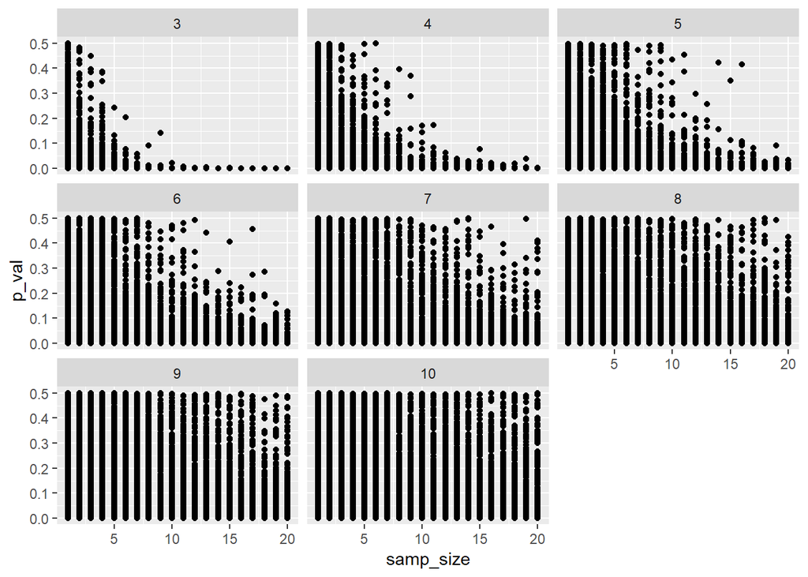

```r
Sim_data <- Sim_data %>%
 mutate(sigma_ybar= SD_val/(sqrt(samp_size))) %>%  #Sigma_y bar formula from slides
  mutate(Z_score= (sample_mean - 80)/sigma_ybar) %>%
  mutate(p_val= pnorm(abs(Z_score), lower.tail = FALSE))%>%
  ungroup()

Sim_plot <- ggplot(data= Sim_data,
                   mapping = aes(x= samp_size, y= p_val))+
  geom_point() +
  facet_wrap(~SD_val)
Sim_plot
```

#### 3.3 P and Power plot power for an alpha of 0.05, but use color for different SD values. Include our threshold power of 0.8.

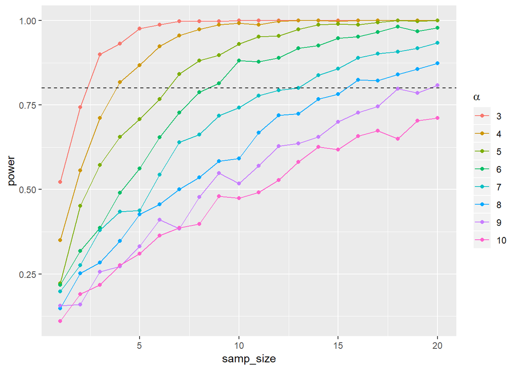

```r
sim_power <- Sim_data %>%
  group_by(SD_val, samp_size) %>%
  summarize(power= 1-sum(p_val>0.05)/n()) %>%
  ungroup()

ggplot(data= sim_power,
       mapping= aes(x= samp_size, y= power, group= SD_val, color= factor(SD_val)))+
         geom_point() +
          geom_line() +
    geom_hline(yintercept= 0.8, lty= 2)+
  scale_color_discrete(guide = guide_legend(title=expression(alpha)))
```

#### 3.4 Many alphas

Last, use `crossing` again to explore changing alphas from 0.01 to 0.1. Plot power curves with different alphas as different colors, and use faceting to look at different SDs.

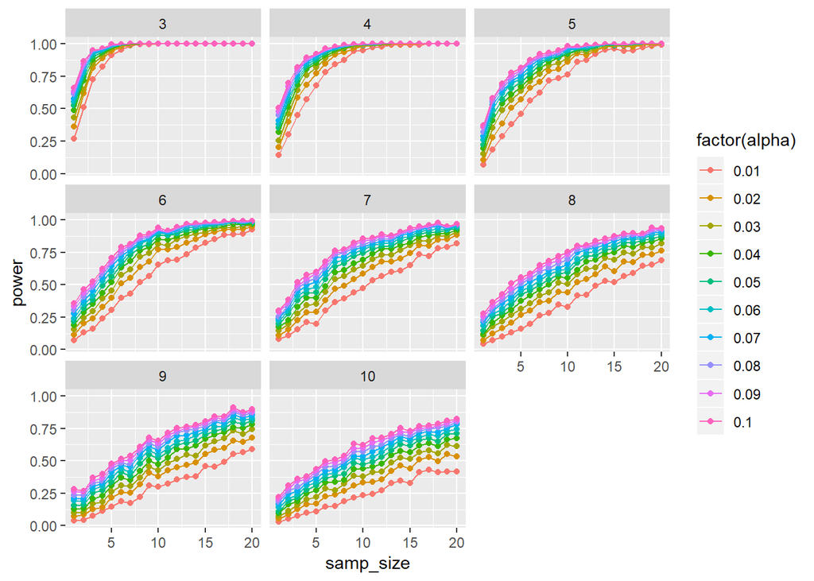

```r
sim_alpha <- Sim_data %>%
  crossing(alpha= seq(0.01, 0.1, .01)) %>%
  group_by(samp_size, SD_val, alpha) %>%
  summarize(power= 1- sum(p_val>alpha)/n()) %>%
  ungroup()

ggplot(data=sim_alpha, mapping=
         aes(x= samp_size, y= power, color= factor(alpha)))+
  geom_point()+
  geom_line() +
  facet_wrap(~SD_val)
```

#### 3.5 What does it all mean? What do you learn about how alpha and SD affect power?

The higher the standard deviation, the larger sample size needed to get a satisfactory power. Increasing alpha increases power, but it leads to trade off of increasing your likelihood of falsely rejecting the null hypothesis.

#### 3.6 How do you think that changing the effect size would affect power?

A bigger effect size would increase power to a point, but if the effect size becomes too large we increase our risk of a Type I error.